# Graduate School Admissions Data Report

Erick Alvarez

December 2, 2024

# Data Set

The data set being examined consists of graduate school admissions. The CSV file being read in is titled “GradSchool_Admissions.csv” as found in the ‘Data’ folder in the BIOL 3100 GitHub repository. A portion of the data frame is seen below:

| admit | gre | gpa | rank |
| --- | --- | --- | --- |
| 0 | 380 | 3.61 | 3 |
| 1 | 660 | 3.67 | 3 |
| 1 | 800 | 4.00 | 1 |
| 1 | 640 | 3.19 | 4 |
| 0 | 520 | 2.93 | 4 |
| 1 | 760 | 3.00 | 2 |

The data consists of 4 columns:

1. **admit**
   - Reflects the acceptance or rejection of a student’s application
     - 1 = Successful (Admitted)
     - 0 = Failure (Rejected)
2. **gre**
   - Reflects the GRE (Graduate Record Examination) score of the individual student
3. **gpa**
   - Reflects the GPA (Grade Point Average) out of 4.0 of the individual student
4. **rank**
   - Reflects the overall ranking of the student’s undergraduate institution
     - Rank of 1 is “Top Tier”
     - Lowest rank is 4

Here is the data structure itself:

```
## 'data.frame':    400 obs. of  4 variables:
##  $ admit: int  0 1 1 1 0 1 1 0 1 0 ...
##  $ gre  : int  380 660 800 640 520 760 560 400 540 700 ...
##  $ gpa  : num  3.61 3.67 4 3.19 2.93 3 2.98 3.08 3.39 3.92 ...
##  $ rank : int  3 3 1 4 4 2 1 2 3 2 ...
```

# Exploratory Data Analysis

I know I want to model admittance outcome predictions according to a student’s institutional rank, GPA, and GRE score. However, I first need to determine which of the predictor variables has the strongest/weakest correlation to the response variable.

The following sections consist of the exploratory data analyses pertaining to these correlations.

## Distribution of Predictor Variables

Firstly, I will be investigating the distribution of the predictor variables on their own so I can infer any hidden trends or patterns that may be important in modeling the admittance predictions.

The following graph is a histogram of the GRE scores across the entire data set:

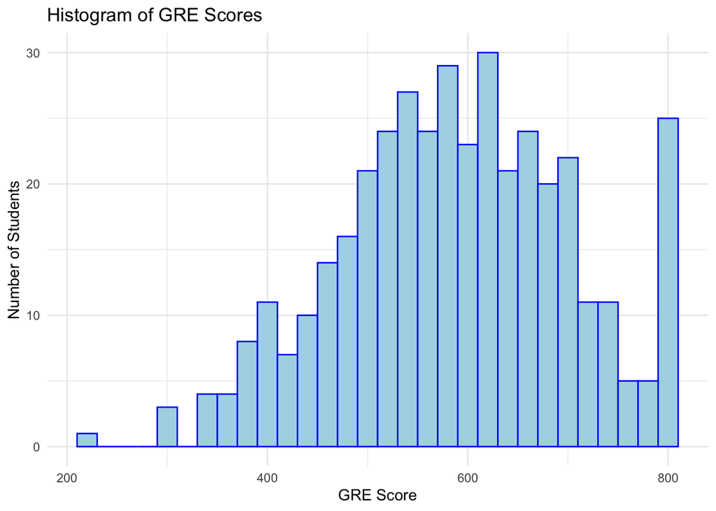

The following table also contains the summary statistics of the same GRE distribution:

| Mean | Median | Standard Deviation | Min | Max | Range | 25th Percentile (Q1) | 75th Percentile (Q3) | Interquartile Range (IQR) |
| --- | --- | --- | --- | --- | --- | --- | --- | --- |
| 587.7 | 580 | 115.516536372238 | 220 | 800 | 580 | 520 | 660 | 140 |

Next is a density plot showing the distribution of the GPA values. I used a density plot since we are dealing with float values instead of whole integers:

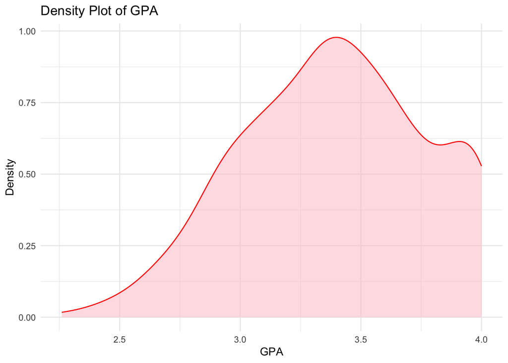

The following table also contains the summary statistics of the same GPA distribution:

| Mean | Median | Standard Deviation | Min | Max | Range | 25th Percentile (Q1) | 75th Percentile (Q3) | Interquartile Range (IQR) |
| --- | --- | --- | --- | --- | --- | --- | --- | --- |
| 3.3899 | 3.395 | 0.380566771630384 | 2.26 | 4 | 1.74 | 3.13 | 3.67 | 0.54 |

Lastly, here is the distribution of undergraduate institutional rankings:

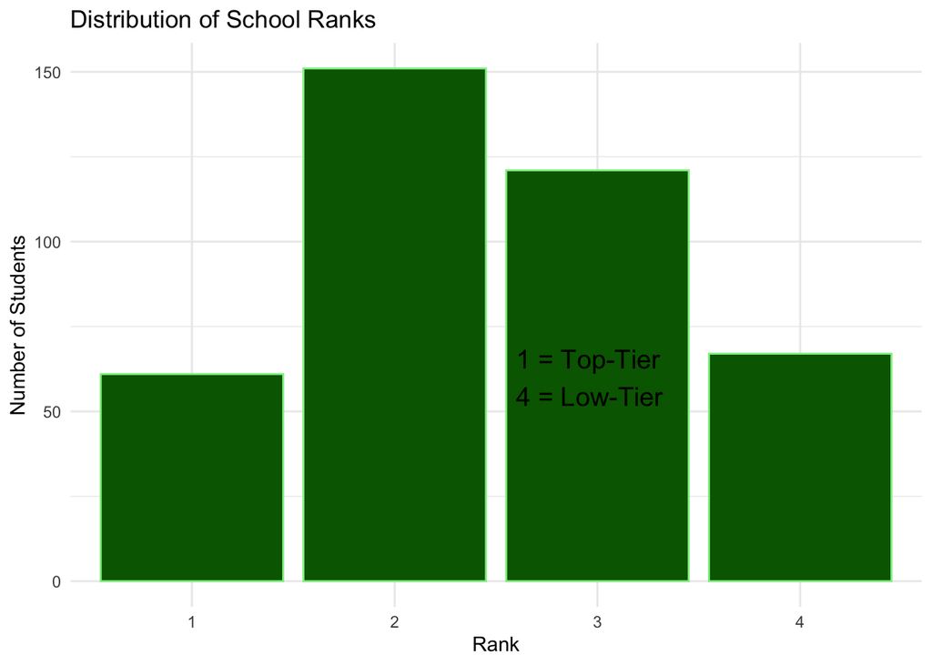

I’m not including any summary statistics for the school rank as any important inference that could be made with categorical data can be easily seen through the graphed visual.

# **Important Note**

YuYa Liang, the professor over this course, has stated that this assignment is actually optional for extra credit and not mandatory so I will not be completing the remainder of this work as I have plenty on my plate at the moment! Sorry (not sorry).